# Raport_inżynierski

Stałe udziały historyczne przeważnie prowadziły do większych błędów niż udziały miesięczne. Wyniki sugerują, że przy rozdzielaniu prognozy ogółem istotne jest uwzględnienie sezonowych zmian struktury dochodów. Dobra prognoza sumy nie gwarantuje jednak trafnego podziału na kategorie. Wnioski mają charakter wstępny i dotyczą badanego okresu testowego.

```r
# ============================================================
# 1. Pakiety i dane
# ============================================================

# Uruchom tylko raz:
# install.packages("corpcor")

library(tidyverse)
library(forecast)

if (!requireNamespace("corpcor", quietly = TRUE)) {
  stop("Najpierw uruchom: install.packages('corpcor')")
}

# Kod korzysta z obiektów z poprzednich etapów:
# szeregi, skladniki, prognozy, bezposrednie, modele,
# ets_ogolem, arima_ogolem

kategorie_rec <- sort(unique(skladniki$kategoria))
wezly_rec <- c("Ogółem", kategorie_rec)

daty_rec <- sort(unique(bezposrednie$data))
poczatek_rec <- min(daty_rec)

# Prognozy bazowe: suma i kategorie prognozowane niezależnie
bazowe_rec <- bind_rows(
  bezposrednie |>
    transmute(model, data, kategoria = "Ogółem", prognoza),
  prognozy |>
    select(model, data, kategoria, prognoza)
) |>
  filter(model %in% c("ARIMA", "ETS"))

rzeczywiste_rec <- szeregi |>
  filter(data %in% daty_rec) |>
  select(data, kategoria, rzeczywiste = mld_usd)

# ============================================================
# 2. Funkcja uzgadniająca prognozy
# ============================================================

# Dla naszej hierarchii jest jeden warunek:
# Ogółem - kategoria_1 - ... - kategoria_7 = 0.
#
# F: wiersze = miesiące, kolumny = szeregi.
# W: macierz wag/kowariancji w tej samej kolejności szeregów.
#
# Wzór jest równoważny standardowemu uzgadnianiu
# metodą ważonych najmniejszych kwadratów dla tej hierarchii.

uzgodnij <- function(F, W) {

  a <- c(1, rep(-1, ncol(F) - 1))

  Wa <- as.numeric(W %*% a)
  mianownik <- sum(a * Wa)

  if (!is.finite(mianownik) || mianownik <= 0) {
    stop("Niepoprawna macierz wag.")
  }

  niespojnosc <- as.numeric(F %*% a)

  F - outer(niespojnosc, Wa / mianownik)
}

# ============================================================
# 3. OLS, WLS i MinT dla ARIMA oraz ETS
# ============================================================

wyniki_rec_lista <- list()
macierze_rec <- list()

for (metoda in c("ARIMA", "ETS")) {

  message("Uzgadnianie prognoz: ", metoda)

  # Prognozy bazowe w macierzy
  szerokie <- bazowe_rec |>
    filter(model == metoda) |>
    select(data, kategoria, prognoza)

  if (anyDuplicated(szerokie[c("data", "kategoria")]) > 0) {
    stop("Powtarzające się prognozy: ", metoda)
  }

  szerokie <- szerokie |>
    pivot_wider(
      names_from = kategoria,
      values_from = prognoza
    ) |>
    arrange(data)

  F <- as.matrix(szerokie[, wezly_rec])

  stopifnot(
    identical(szerokie$data, daty_rec),
    all(is.finite(F))
  )

  # Modele dopasowane wcześniej wyłącznie na treningu
  model_sumy <- if (metoda == "ARIMA") {
    arima_ogolem
  } else {
    ets_ogolem
  }

  modele_dol <- lapply(
    kategorie_rec,
    function(kat) modele[[kat]][[metoda]]
  )

  modele_wszystkie <- c(list(model_sumy), modele_dol)
  names(modele_wszystkie) <- wezly_rec

  # Sprawdzenie, czy modele korzystały z właściwego treningu
  for (kat in wezly_rec) {

    oczekiwany_trening <- szeregi |>
      filter(kategoria == kat, data < poczatek_rec) |>
      arrange(data) |>
      pull(mld_usd)

    trening_modelu <- as.numeric(modele_wszystkie[[kat]]$x)

    if (!isTRUE(all.equal(
      trening_modelu,
      oczekiwany_trening,
      check.attributes = FALSE
    ))) {
      stop("Model ma inny trening: ", metoda, " / ", kat)
    }
  }

  # Reszty wyrównane według czasu
  reszty_lista <- lapply(
    modele_wszystkie,
    function(m) residuals(m)
  )

  E <- as.matrix(do.call(stats::ts.intersect, reszty_lista))
  colnames(E) <- wezly_rec

  # Pomijamy pierwsze 12 miesięcy, aby ograniczyć
  # wpływ inicjalizacji modeli.
  if (nrow(E) <= 36) {
    stop("Za mało reszt do oszacowania macierzy wag.")
  }

  E <- E[-seq_len(12), , drop = FALSE]

  # Wszystkie kowariancje liczymy na tych samych miesiącach
  E <- E[
    apply(E, 1, function(x) all(is.finite(x))),
    ,
    drop = FALSE
  ]

  stopifnot(nrow(E) >= 24)

  wariancje <- apply(E, 2, var)

  if (any(!is.finite(wariancje)) || any(wariancje <= 0)) {
    stop("Zerowa lub niepoprawna wariancja reszt.")
  }

  # OLS: macierz jednostkowa
  W_ols <- diag(length(wezly_rec))

  # WLS: wariancje reszt na przekątnej
  W_wls <- diag(wariancje)

  # MinT: kowariancja ze shrinkage korelacji.
  # lambda.var = 0 pozostawia wariancje bez shrinkage.
  W_mint <- corpcor::cov.shrink(
    E,
    lambda.var = 0,
    verbose = FALSE
  )

  macierze_rec[[metoda]] <- list(
    OLS = W_ols,
    WLS = W_wls,
    MinT = W_mint
  )

  # Bottom-up: zachowujemy dół, zastępujemy sumę
  F_bu <- F
  F_bu[, 1] <- rowSums(F[, -1, drop = FALSE])

  warianty <- list(
    "Niezależne" = F,
    "Bottom-up" = F_bu,
    "OLS" = uzgodnij(F, W_ols),
    "WLS" = uzgodnij(F, W_wls),
    "MinT-shrink" = uzgodnij(F, W_mint)
  )

  wyniki_rec_lista[[metoda]] <- purrr::imap_dfr(
    warianty,
    function(M, nazwa) {

      colnames(M) <- wezly_rec

      as_tibble(M) |>
        mutate(data = daty_rec) |>
        pivot_longer(
          cols = all_of(wezly_rec),
          names_to = "kategoria",
          values_to = "prognoza"
        ) |>
        mutate(
          model = metoda,
          podejscie = nazwa
        )
    }
  )
}
```

```
## Uzgadnianie prognoz: ARIMA
```

```
## Uzgadnianie prognoz: ETS
```

```r
prognozy_rec <- bind_rows(wyniki_rec_lista)

# ============================================================
# 4. Dodanie wcześniejszych wyników top-down, jeśli istnieją
# ============================================================

if (exists("top_down")) {

  td_dol_rec <- top_down |>
    filter(model %in% c("ARIMA", "ETS")) |>
    select(model, podejscie, data, kategoria, prognoza)

  # W top-down prognoza ogółem pozostaje bezpośrednia
  td_gora_rec <- td_dol_rec |>
    distinct(model, podejscie, data) |>
    left_join(
      bezposrednie |> select(model, data, prognoza),
      by = c("model", "data")
    ) |>
    mutate(kategoria = "Ogółem")

  prognozy_rec <- bind_rows(
    prognozy_rec, td_dol_rec, td_gora_rec
  )
}

# ============================================================
# 5. Kontrola spójności
# ============================================================

kontrola_rec <- prognozy_rec |>
  group_by(model, podejscie, data) |>
  summarise(
    roznica = sum(prognoza[kategoria == "Ogółem"]) -
      sum(prognoza[kategoria != "Ogółem"]),
    .groups = "drop"
  ) |>
  group_by(model, podejscie) |>
  summarise(
    maks_niespojnosc = max(abs(roznica)),
    .groups = "drop"
  )

print(kontrola_rec, n = Inf)
```

```
## # A tibble: 14 × 3
##    model podejscie     maks_niespojnosc
##    <chr> <chr>                    <dbl>
##  1 ARIMA Bottom-up             0
##  2 ARIMA MinT-shrink           5.68e-14
##  3 ARIMA Niezależne            1.00e+ 2
##  4 ARIMA OLS                   5.68e-14
##  5 ARIMA TD miesięczny         5.68e-14
##  6 ARIMA TD stały              2.84e-14
##  7 ARIMA WLS                   5.68e-14
##  8 ETS   Bottom-up             0
##  9 ETS   MinT-shrink           5.68e-14
## 10 ETS   Niezależne            1.87e+ 1
## 11 ETS   OLS                   5.68e-14
## 12 ETS   TD miesięczny         5.68e-14
## 13 ETS   TD stały              0
## 14 ETS   WLS                   5.68e-14
```

```r
# Prognozy niezależne mogą być niespójne.
# Wszystkie pozostałe powinny sumować się poprawnie.
stopifnot(
  all(
    kontrola_rec$maks_niespojnosc[
      kontrola_rec$podejscie != "Niezależne"
    ] < 1e-6
  )
)

# ============================================================
# 6. Błędy na tym samym teście
# ============================================================

ocena_rec <- prognozy_rec |>
  left_join(
    rzeczywiste_rec,
    by = c("data", "kategoria")
  )

stopifnot(
  all(is.finite(ocena_rec$rzeczywiste)),
  all(is.finite(ocena_rec$prognoza))
)

bledy_rec <- ocena_rec |>
  group_by(model, podejscie, kategoria) |>
  summarise(
    MAE = mean(abs(rzeczywiste - prognoza)),
    RMSE = sqrt(mean((rzeczywiste - prognoza)^2)),
    .groups = "drop"
  )

# Zmiana RMSE względem prognoz niezależnych
odniesienie_rec <- bledy_rec |>
  filter(podejscie == "Niezależne") |>
  select(model, kategoria, RMSE_bazowy = RMSE)

bledy_rec <- bledy_rec |>
  left_join(odniesienie_rec, by = c("model", "kategoria")) |>
  mutate(
    poprawa_proc = if_else(
      RMSE_bazowy > 0,
      100 * (1 - RMSE / RMSE_bazowy),
      NA_real_
    )
  )

# Wyniki dla dochodów ogółem
bledy_rec |>
  filter(kategoria == "Ogółem") |>
  arrange(model, RMSE) |>
  mutate(across(where(is.numeric), ~ round(.x, 3))) |>
  print(n = Inf)
```

```
## # A tibble: 14 × 7
##    model podejscie     kategoria   MAE  RMSE RMSE_bazowy poprawa_proc
##    <chr> <chr>         <chr>     <dbl> <dbl>       <dbl>        <dbl>
##  1 ARIMA Niezależne    Ogółem     84.9  119.        119.        0
##  2 ARIMA TD miesięczny Ogółem     84.9  119.        119.        0
##  3 ARIMA TD stały      Ogółem     84.9  119.        119.        0
##  4 ARIMA OLS           Ogółem     85.5  122.        119.       -2.46
##  5 ARIMA MinT-shrink   Ogółem     87.6  131.        119.      -10.3
##  6 ARIMA WLS           Ogółem     87.9  132.        119.      -11.1
##  7 ARIMA Bottom-up     Ogółem     91.8  145.        119.      -21.9
##  8 ETS   Niezależne    Ogółem     94.6  124.        124.        0
##  9 ETS   TD miesięczny Ogółem     94.6  124.        124.        0
## 10 ETS   TD stały      Ogółem     94.6  124.        124.        0
## 11 ETS   OLS           Ogółem     95.0  124.        124.       -0.113
## 12 ETS   WLS           Ogółem     96.1  125.        124.       -0.547
## 13 ETS   MinT-shrink   Ogółem     96.1  125.        124.       -0.55
## 14 ETS   Bottom-up     Ogółem     97.4  126.        124.       -1.08
```

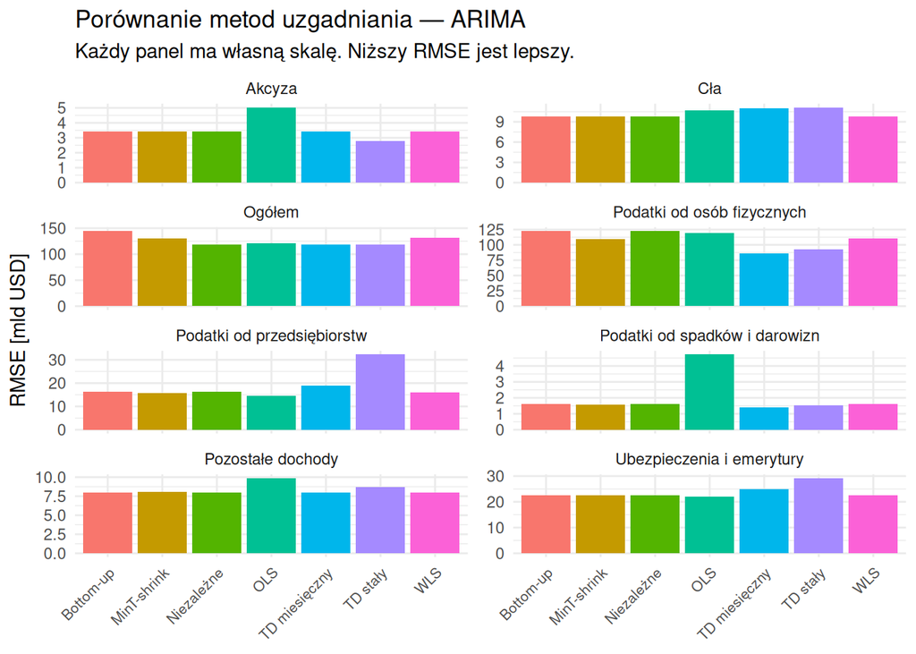

```r
# ============================================================
# 7. Wykres dla wszystkich poziomów — wybierz ARIMA lub ETS
# ============================================================

wybrany_model_rec <- "ARIMA"

p_rec <- bledy_rec |>
  filter(model == wybrany_model_rec) |>
  ggplot(aes(podejscie, RMSE, fill = podejscie)) +
  geom_col() +
  facet_wrap(~ kategoria, scales = "free_y", ncol = 2) +
  labs(
    title = paste(
      "Porównanie metod uzgadniania —", wybrany_model_rec
    ),
    subtitle = "Każdy panel ma własną skalę. Niższy RMSE jest lepszy.",
    x = NULL,
    y = "RMSE [mld USD]"
  ) +
  theme_minimal() +
  theme(
    legend.position = "none",
    axis.text.x = element_text(
      angle = 45, hjust = 1, size = 8
    )
  )

print(p_rec)
```

```r
# Dokładne wyniki dla wybranego modelu
bledy_rec |>
  filter(model == wybrany_model_rec) |>
  arrange(kategoria, RMSE) |>
  select(kategoria, podejscie, MAE, RMSE, poprawa_proc) |>
  mutate(across(where(is.numeric), ~ round(.x, 3))) |>
  print(n = Inf)
```

```
## # A tibble: 56 × 5
##    kategoria                     podejscie        MAE   RMSE poprawa_proc
##    <chr>                         <chr>          <dbl>  <dbl>        <dbl>
##  1 Akcyza                        TD stały       1.99    2.80       18.3
##  2 Akcyza                        MinT-shrink    2.48    3.42        0.318
##  3 Akcyza                        WLS            2.48    3.42        0.316
##  4 Akcyza                        Bottom-up      2.48    3.43        0
##  5 Akcyza                        Niezależne     2.48    3.43        0
##  6 Akcyza                        TD miesięczny  2.09    3.43       -0.134
##  7 Akcyza                        OLS            4.14    5.03      -46.8
##  8 Cła                           MinT-shrink    5.97    9.83        0.006
##  9 Cła                           WLS            5.97    9.84        0.001
## 10 Cła                           Bottom-up      5.97    9.84        0
## 11 Cła                           Niezależne     5.97    9.84        0
## 12 Cła                           OLS            7.12   10.6        -8.26
```

[output cut: 44 more lines]

W analizowanym okresie testowym metody OLS, WLS i MinT nie przyniosły wyraźnej, systematycznej poprawy trafności prognoz względem niezależnych modeli ARIMA. Wyniki WLS i MinT były na ogół zbliżone do prognoz bazowych. OLS silniej zmieniał wyniki poszczególnych szeregów: ewentualnym korzyściom na poziomie sumy towarzyszyło pogorszenie prognoz niektórych kategorii, szczególnie akcyzy oraz podatków od spadków i darowizn.

Uzgadnianie zapewniło jednak spójność prognoz, czyli zgodność prognozy dochodów ogółem z sumą prognoz kategorii. W przypadku WLS i MinT uzyskano ją bez dużych zmian trafności widocznych na wykresie. Wyniki wskazują zatem, że w tym eksperymencie główną korzyścią tych metod była spójność, a nie wyraźne zmniejszenie błędów.

Nie oznacza to ogólnej nieskuteczności uzgadniania prognoz. Ocena dotyczy jednego okresu testowego oraz konkretnego sposobu estymacji macierzy wag na podstawie reszt treningowych. Dalsza analiza powinna sprawdzić stabilność wyników dla różnych momentów rozpoczęcia prognozowania i horyzontów.

# Dane

## Bottom - Up

## Top - Down

## Middle - Out

## Forecast Reconciliation

## OLS

## WLS

## MinT